# Statistics of MLB

Josh Chang

2018/3/17

## Introduction

這次的R Markdown 視覺化分析作業 想探討 在過去這一年 MLB中的眾多打擊數據中 哪個跟勝場數最有關係～

通常我們在衡量一個選手時 最常注意的就是他的打擊率跟全壘打數 如果打擊率高 代表你擊出安打的比率高 如果你的全壘打很多 則代表你能一棒就讓球隊的得分變高 然而 其實還有一些我們熟知 但卻又不是那麼看重的數據 像是二壘 三壘安打數 盜壘 等等 到底在去年中 哪項數據跟球隊的勝場是最具有相關性的呢？

以下我會採用國外網站所提供的各項打擊數據 先觀察圖表的特性 看看哪項數據最接近一直線(代表相關性最大) 最後再用相關係數的函式cor()來驗證我得到的結果！

## R crawler

```r
library(XML)
library(rvest)
library(dplyr)
#爬取30支球隊全壘打的數量
homeruns <- read_html("https://www.baseball-reference.com/leagues/MLB/2017.shtml")
homerunstitle <- c("tbody td.left+ .right")
HR <- html_nodes(homeruns,homerunstitle)
HR <- html_text(HR)
HR <- iconv(HR,"UTF-8")
HR <- HR[1:30]
#HR



#爬取30支球隊的名稱
teams <- read_html("https://www.baseball-reference.com/teams/")
teamstitle <- c("#teams_active .left a")
Team <- html_nodes(teams,teamstitle)
Team <- html_text(Team)
Team <- iconv(Team,"UTF-8")
#Team

df1 = data.frame(Team, HR)

#爬取30支球隊的戰績
winloses <- read_html("http://www.espn.com/mlb/standings/_/sort/gamesbehind/dir/asc/season/2017/group/overall")
winlosestitle <- c(".Table2__td:nth-child(1) .stat-cell , .hide-mobile a")
Winlose <- html_nodes(winloses,winlosestitle)
Winlose <- html_text(Winlose)
Winlose <- iconv(Winlose,"UTF-8")
#Winlose

df2 <- data.frame(Winlose[1:30],Winlose[31:60])

winlosestitle <- c(".Table2__td:nth-child(2) .stat-cell")
Winlose <- html_nodes(winloses,winlosestitle)
Winlose <- html_text(Winlose)
Winlose <- iconv(Winlose,"UTF-8")
df2 <- data.frame(df2,Winlose[1:30])
names(df2) <- c("Team", "Wins", "Loses")

#將兩個表格合併
df <- merge(df1, df2, by = "Team")

#抓取球隊分別位於的兩聯盟
areas <- read_html("https://www.cbssports.com/mlb/teams")
areastitle <- c(".title td , td > a+ a")
Areas <- html_nodes(areas,areastitle)
Areas <- html_text(Areas)
Areas <- iconv(Areas,"UTF-8")
#Areas

df2 <- data.frame(union(Areas[2:16] ,Areas[18:32]))
df2$Areas[1:15] <- Areas[1]
df2$Areas[16:30] <- Areas[17]
names(df2) <- c("Team","Conference")
df <- merge(df, df2, by = "Team")

#更多數據 ex:2B 3B 盜壘 被三振
stats <- read_html("https://www.baseball-reference.com/leagues/MLB/2017.shtml")
statstitle <- c("#teams_standard_batting tbody .right:nth-child(18) , #teams_standard_batting tbody .right:nth-child(14) , #teams_standard_batting tbody td.left")
stat <- html_nodes(stats,statstitle)
stat <- html_text(stat)
stat <- iconv(stat,"UTF-8")
#stat
count <- 1
Double <- c()
Triple <- c()
Stolen <- c()
Batting <- c()
while(count <= 120){
  if(count %% 4 == 0){
    Batting[count / 4 ] <- stat[count]
  }else if(count %% 4 == 1){
    Double[count / 4 + 1] <- stat[count]
  }else if(count %% 4 == 2){
    Triple[count / 4 + 1] <- stat[count]
  }else{
    Stolen[count / 4 + 1] <- stat[count]
  }
  count <- count + 1
}
df$Double <- as.numeric(Double)
df$Triple <- as.numeric(Triple)
df$Stolen <- as.numeric(Stolen)
df$Batting <- as.numeric(Batting)

df$Wins <- as.numeric(as.character(df$Wins))
df$HR <- as.numeric(as.character(df$HR))
df <- arrange(df,desc(Wins))
```

## Team Statistics

```r
library(ggplot2)
df
```

```
##                     Team  HR Wins Loses      Conference Double Triple
## 1    Los Angeles Dodgers 221  104    58 National League    312     20
## 2      Cleveland Indians 212  102    60 American League    333     29
## 3         Houston Astros 238  101    61 American League    346     20
## 4   Washington Nationals 215   97    65 National League    311     31
## 5   Arizona Diamondbacks 220   93    69 National League    314     39
## 6         Boston Red Sox 168   93    69 American League    302     19
## 7           Chicago Cubs 223   92    70 National League    274     29
## 8       New York Yankees 241   91    71 American League    266     23
## 9       Colorado Rockies 192   87    75 National League    293     38
## 10     Milwaukee Brewers 224   86    76 National League    267     22
## 11       Minnesota Twins 206   85    77 American League    286     31
## 12   St. Louis Cardinals 196   83    79 National League    284     28
## 13    Kansas City Royals 193   80    82 American League    260     24
## 14    Los Angeles Angels 186   80    82 American League    251     14
```

[output cut: 47 more lines]

## Team Conferences

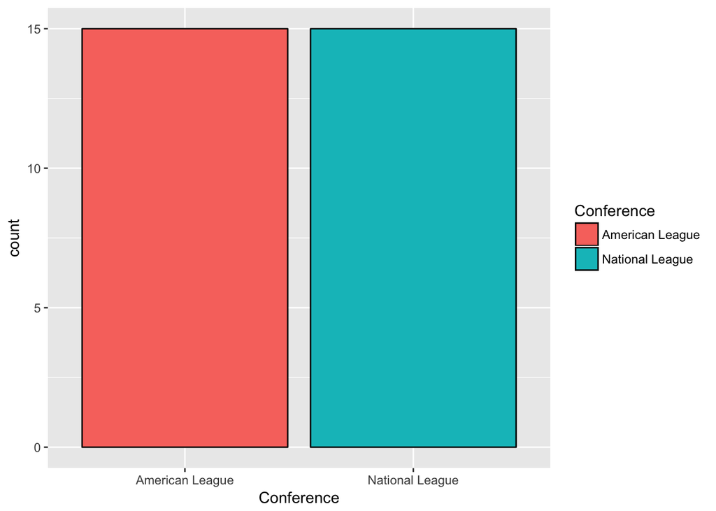

```r
ggplot(data = df,
  aes(x = Conference,fill = Conference))+
  geom_bar(colour = "black")
```

## Records

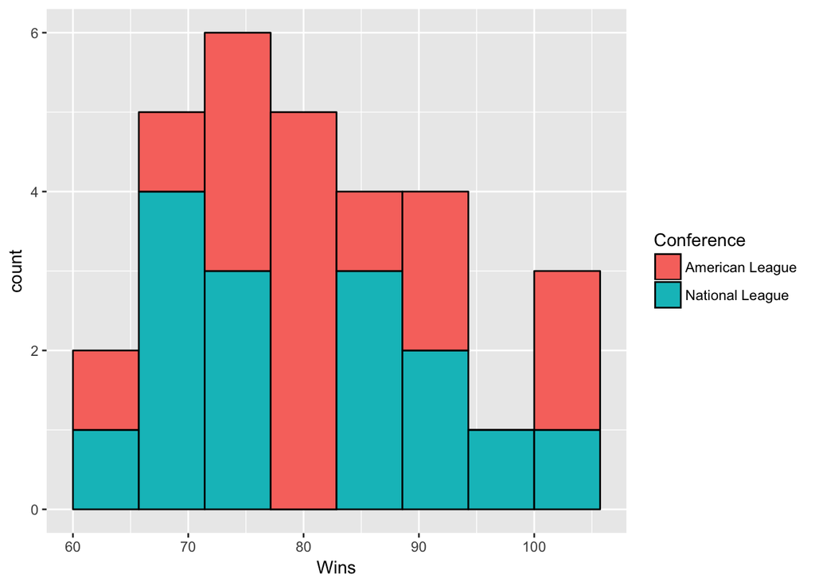

```r
ggplot(data = df, aes(x = Wins,fill = Conference)) +
geom_histogram(bins = 8,colour="black")
```

## Homeruns v.s. records

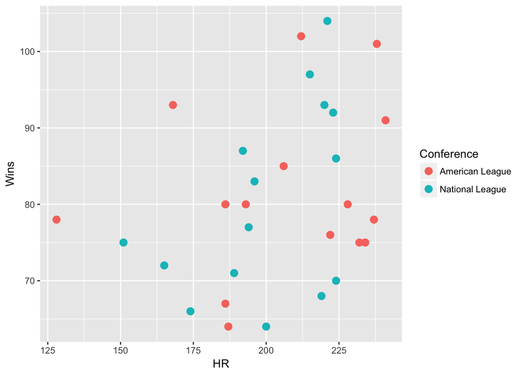

```r
ggplot(data = df, aes(x = HR, y=Wins)) +
geom_point(aes(colour = Conference),size =3)
```

## Doubles v.s. records

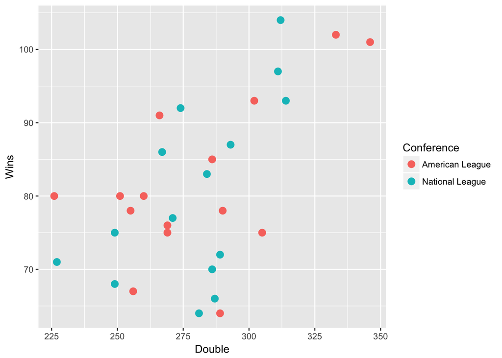

```r
ggplot(data = df, aes(x = Double, y=Wins)) +
geom_point(aes(colour = Conference),size =3)
```

## Triples v.s. records

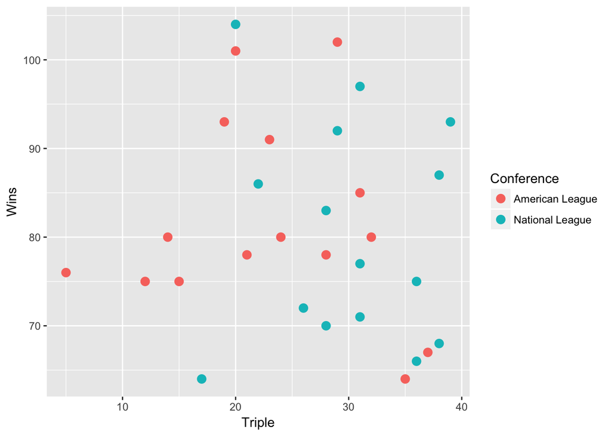

```r
ggplot(data = df, aes(x = Triple, y=Wins)) +
geom_point(aes(colour = Conference),size =3)
```

## Stolens v.s. records

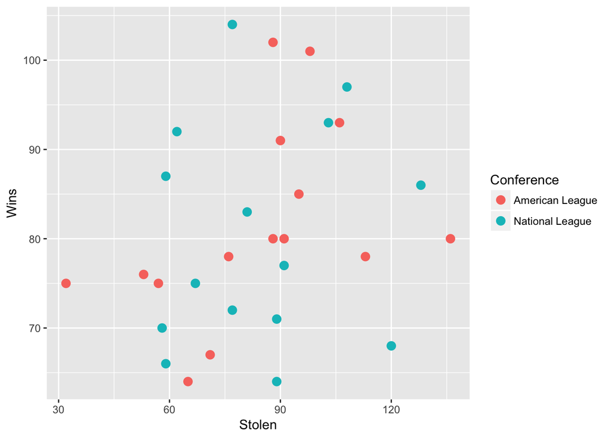

```r
ggplot(data = df, aes(x = Stolen, y=Wins)) +
geom_point(aes(colour = Conference),size =3)
```

## Batting v.s. records

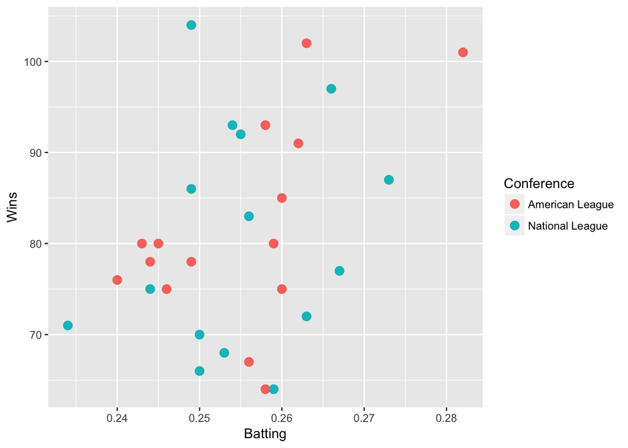

```r
ggplot(data = df, aes(x = Batting, y=Wins)) +
geom_point(aes(colour = Conference),size =3)
```

## Conclusion

從以上的圖來看 結果看起來跟我當初想像的有點出入 其中 看起來最像一條直線的 竟然不是打擊率跟全壘打數 而是二壘安打數 而三壘安打跟盜壘跟戰績明顯地看出不是十分相關

最後我們用 函式再來檢查看看吧～

```r
cor(df$HR,df$Wins)
```

```
## [1] 0.321188
```

```r
cor(df$Double,df$Wins)
```

```
## [1] 0.5721162
```

```r
cor(df$Triple,df$Wins)
```

```
## [1] -0.1049604
```

```r
cor(df$Stolen,df$Wins)
```

```
## [1] 0.2766185
```

```r
cor(df$Batting,df$Wins)
```

```
## [1] 0.3788597
```

結果就跟我們上面的圖一樣 二壘安打跟勝場數的相關係數來到0.57 也是上面數據中最高的 其他幾項也都有差不多0.3上下的相關係數 而令人比較意外的是 三壘安打數 竟然是呈現負相關(-0.1) 雖然不大 但仍可以看出 一支球隊的戰力 可能跟他能擊出多少支三壘安打沒有正向的關係 更多的可能是運氣及速度的成分

說到速度 那讓我們來做最後一個觀察 會盜壘的人 肯定跑步速度很快 那它跟三壘安打的相關性呢?

## Triples v.s. Stolen

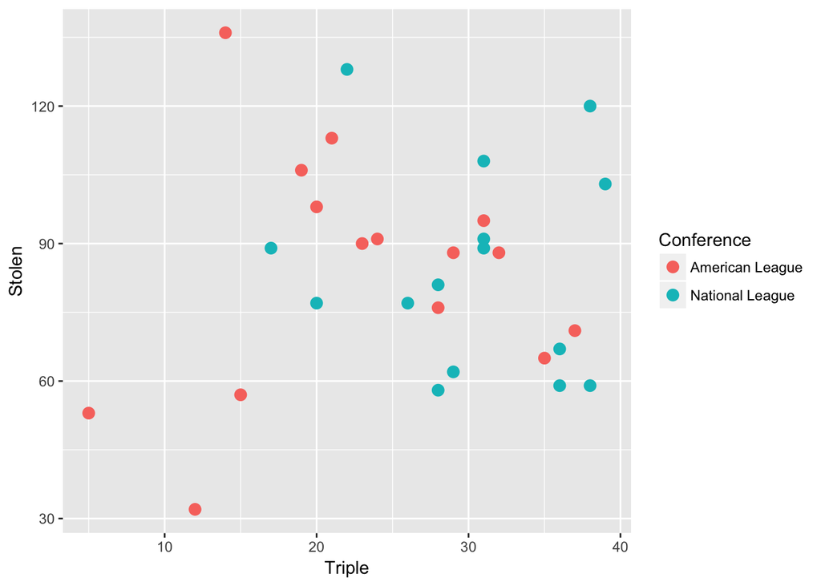

```r
ggplot(data = df, aes(x = Triple, y=Stolen)) +
geom_point(aes(colour = Conference),size =3)
```

```r
cor(df$Triple , df$Stolen)
```

```
## [1] 0.0384452
```

結果顯示 這兩者幾乎沒有相關QQ 而也間接說明了三壘安打的產生 真的有很大一部分是需要機遇的 然而 棒球場上除了打擊數據外 投手也是另一項很重要的環節 所以可能有些球隊的全壘打打非常多 但 他們的投手可能也讓對方得了很多分 導致戰績不如預期 這也是非常有可能發生的事

不過 從這次的分析來看 我們確實能知道 除了全壘打和打擊率以外 二壘安打的數量 也是非常重要的數據 而這項數據也確實可以跟一支球隊的戰績有正面的相關！